# Proteomic consistency metrics – Development Version with static metrics, v3

Simina Boca, Shaojun Tang, Yi Bai, Nathan Edwards

August 31, 2017

## Data file

We used the “CompRefBI_mzml_metricInfo_all_id.07272017.tsv” data file to generate this report. To see the data file in tsv format, please click

**Here**

## PDF file

To view the generated PDF file, please click **Here**

## Number of MS2 spectra

### Per sample, across fraction (boxplot) , separate scales

This graph represents boxplot of the number of MS2 spectra across fraction versus the analytical sample in separate scales. Each analytical sample is represented by a different color.

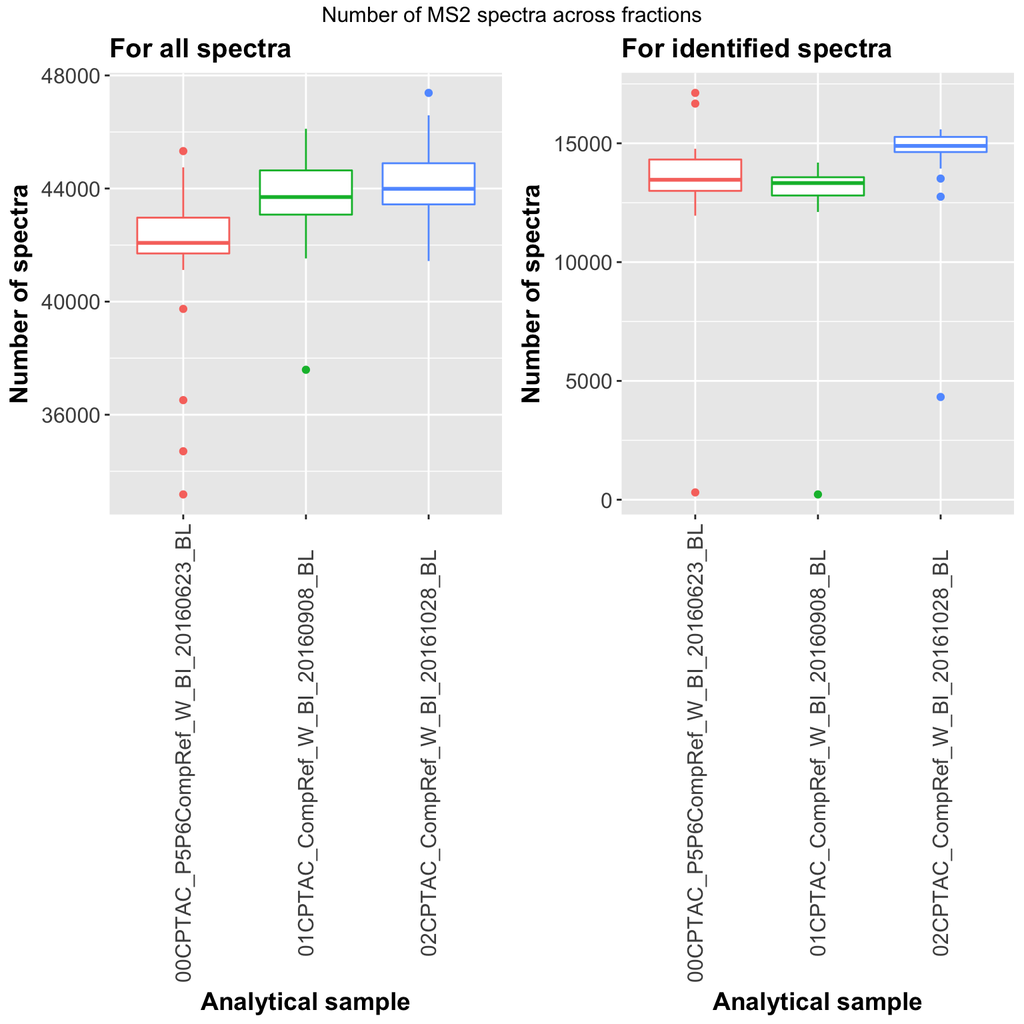

### Per sample, across fraction (boxplot), with the same scale

This graph represents box plot of the number of MS2 spectra across fraction versus the analytical sample in the same scale. Each analytical sample is represented by a different color.

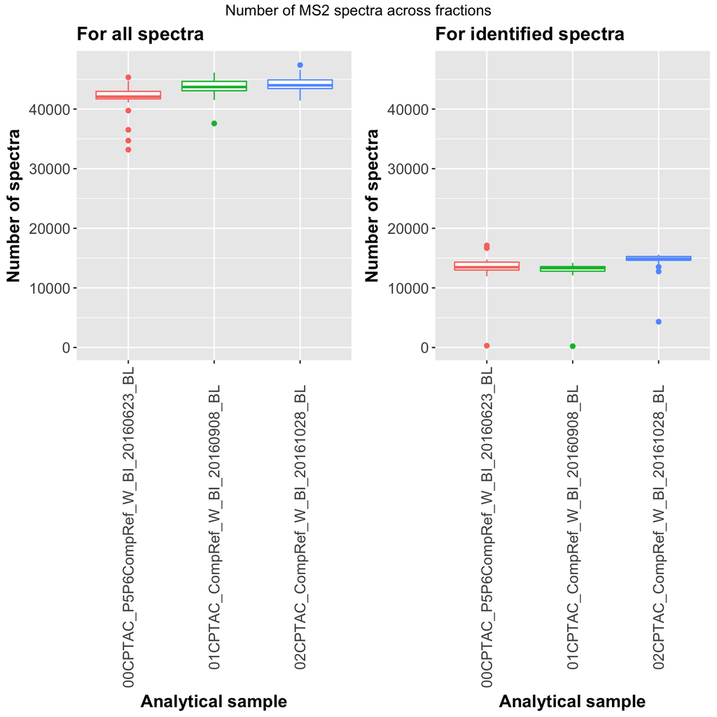

### Per sample, versus fraction (scatterplot), separate scales

This graph represents scatter plot of the number of MS2 spectra versus fractions in separate scales. Each analytical sample is represented by a different color. The grey area represent the 95% confidence interval for each sample

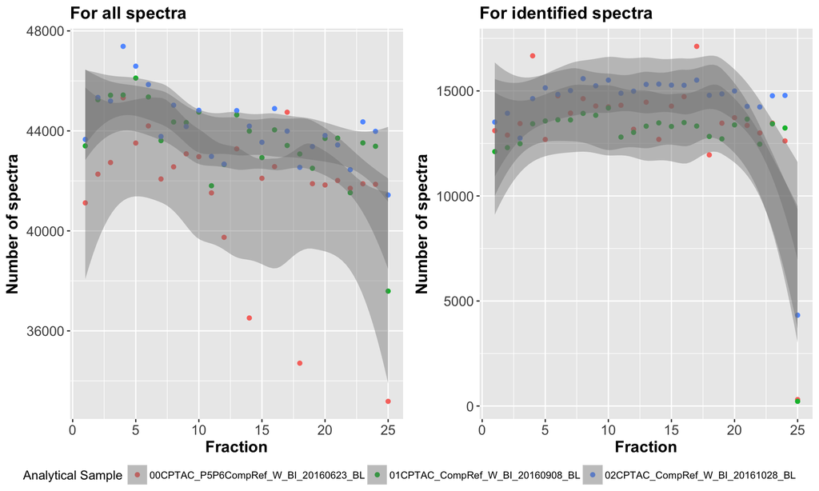

### Per sample, versus fraction (scatterplot), same scale

This graph represents scatter plot of the number of MS2 spectra versus fractions in the same scale. Each analytical sample is represented by a different color. The grey area represent the 95% confidence interval for each sample

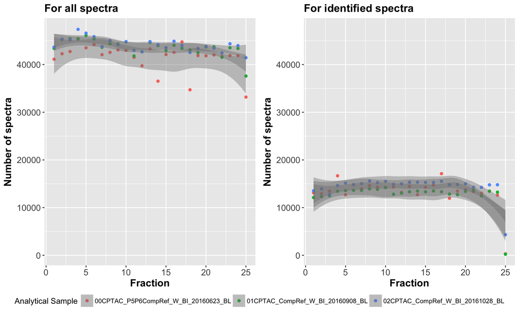

### Number of MS2 spectra versus fraction (boxplot), separate scale

This graph represents box plot of the number of MS2 spectra versus fractions in separate scales. Each analytical sample is represented by a different color. The grey area represent the 95% confidence interval for each sample

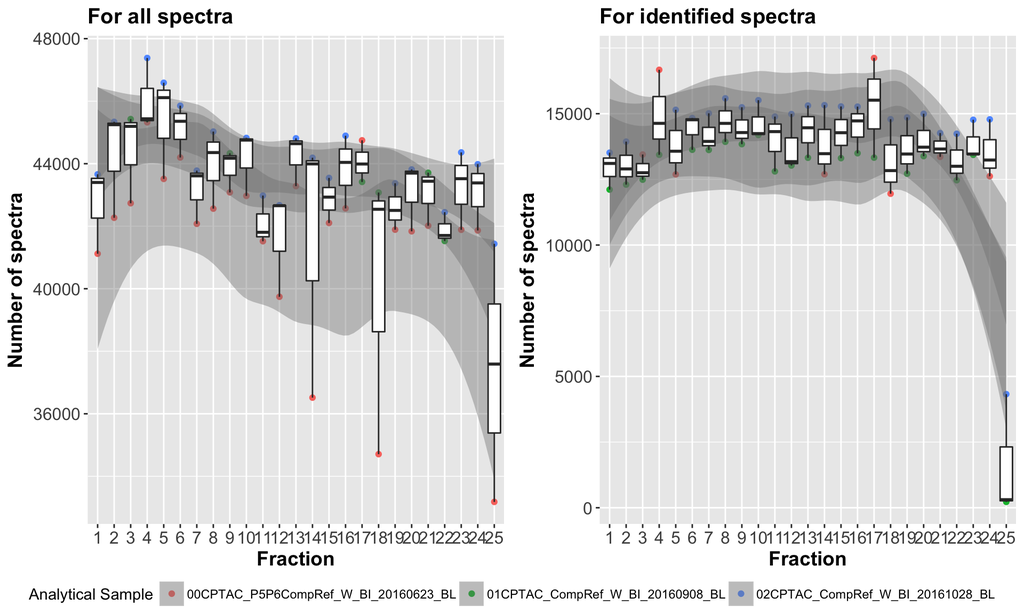

### Number of MS2 spectra versus fraction (boxplot), same scale

This graph represents boxplot of the number of MS2 spectra versus fractions in the same scale. Each analytical sample is represented by a different color. The grey area represent the 95% confidence interval for each sample

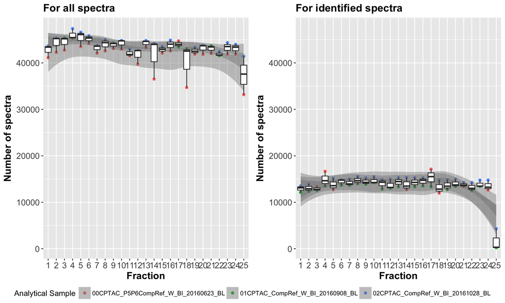

## Precursor intensity values

### Range of Precursor intensity values For all spectra

This table shows the range of the precursor intensity for each percentile, as a summary and to see if there are any value of 0 that cannot be log-transformed

|  | 5th Perc | 25th perc | 50th perc | 75th perc | 95th perc |
| --- | --- | --- | --- | --- | --- |
| range | 0, 0 | 13921.04, 2785124.75 | 50261.56, 8182241.5 | 140378.73, 20557060 | 1450821.96, 86219475.2 |
| range of log10 transformed | -Inf, -Inf | 4.14, 6.44 | 4.7, 6.91 | 5.15, 7.31 | 6.16, 7.94 |

### Range of Precursor intensity values For identified spectra

This table shows the range of the precursor intensity for each percentile, as a summary and to see if there are any value of 0 that cannot be log-transformed

|  | 5th Perc | 25th perc | 50th perc | 75th perc | 95th perc |
| --- | --- | --- | --- | --- | --- |
| range | 0, 105641.58 | 190316.07, 5425278 | 394277.41, 12651390 | 992609.34, 30232546 | 6000430.85, 131598537.6 |
| range of log10 transformed | -Inf, 5.02 | 5.28, 6.73 | 5.6, 7.1 | 6, 7.48 | 6.78, 8.12 |

### Per sample, versus fraction (scatterplot)

This graph represents scatter plot of the 5%,25%,50%,75%,95% for precursor intensity values versus fractions in the same scale. Each panel is a different percentile. Each analytical sample is represented by a different color.

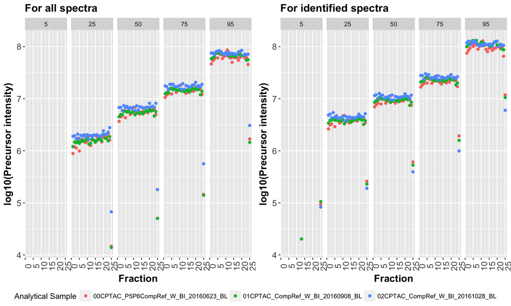

### Percentage of 0 precursor intensities at different percentiles, For all spectra

In this table, each row represents a fraction and each column represents a percentile. Each value represents the percent of samples that have a precursor intensity of 0 at that fraction and that percentile.

|  | 5th Perc | 25th Perc | 50th Perc | 75th Perc | 95th Perc |
| --- | --- | --- | --- | --- | --- |
| fraction1 | 100 | 0 | 0 | 0 | 0 |
| fraction2 | 100 | 0 | 0 | 0 | 0 |
| fraction3 | 100 | 0 | 0 | 0 | 0 |
| fraction4 | 100 | 0 | 0 | 0 | 0 |
| fraction5 | 100 | 0 | 0 | 0 | 0 |
| fraction6 | 100 | 0 | 0 | 0 | 0 |
| fraction7 | 100 | 0 | 0 | 0 | 0 |
| fraction8 | 100 | 0 | 0 | 0 | 0 |
| fraction9 | 100 | 0 | 0 | 0 | 0 |
| fraction10 | 100 | 0 | 0 | 0 | 0 |
| fraction11 | 100 | 0 | 0 | 0 | 0 |
| fraction12 | 100 | 0 | 0 | 0 | 0 |
| fraction13 | 100 | 0 | 0 | 0 | 0 |
| fraction14 | 100 | 0 | 0 | 0 | 0 |
| fraction15 | 100 | 0 | 0 | 0 | 0 |
| fraction16 | 100 | 0 | 0 | 0 | 0 |
| fraction17 | 100 | 0 | 0 | 0 | 0 |
| fraction18 | 100 | 0 | 0 | 0 | 0 |
| fraction19 | 100 | 0 | 0 | 0 | 0 |
| fraction20 | 100 | 0 | 0 | 0 | 0 |
| fraction21 | 100 | 0 | 0 | 0 | 0 |
| fraction22 | 100 | 0 | 0 | 0 | 0 |
| fraction23 | 100 | 0 | 0 | 0 | 0 |
| fraction24 | 100 | 0 | 0 | 0 | 0 |
| fraction25 | 100 | 0 | 0 | 0 | 0 |

### Percentage of 0 precursor intensities at different percentiles, For identified spectra

In this table, each row represents a fraction and each column represents a percentile. Each value represents the percent of samples that have a precursor intensity of 0 at that fraction and that percentile.

|  | 5th Perc | 25th Perc | 50th Perc | 75th Perc | 95th Perc |
| --- | --- | --- | --- | --- | --- |
| fraction1 | 100.000 | 0 | 0 | 0 | 0 |
| fraction2 | 100.000 | 0 | 0 | 0 | 0 |
| fraction3 | 100.000 | 0 | 0 | 0 | 0 |
| fraction4 | 100.000 | 0 | 0 | 0 | 0 |
| fraction5 | 100.000 | 0 | 0 | 0 | 0 |
| fraction6 | 100.000 | 0 | 0 | 0 | 0 |
| fraction7 | 100.000 | 0 | 0 | 0 | 0 |
| fraction8 | 100.000 | 0 | 0 | 0 | 0 |
| fraction9 | 100.000 | 0 | 0 | 0 | 0 |
| fraction10 | 100.000 | 0 | 0 | 0 | 0 |
| fraction11 | 100.000 | 0 | 0 | 0 | 0 |
| fraction12 | 100.000 | 0 | 0 | 0 | 0 |
| fraction13 | 66.667 | 0 | 0 | 0 | 0 |
| fraction14 | 100.000 | 0 | 0 | 0 | 0 |
| fraction15 | 100.000 | 0 | 0 | 0 | 0 |
| fraction16 | 100.000 | 0 | 0 | 0 | 0 |
| fraction17 | 100.000 | 0 | 0 | 0 | 0 |
| fraction18 | 100.000 | 0 | 0 | 0 | 0 |
| fraction19 | 100.000 | 0 | 0 | 0 | 0 |
| fraction20 | 100.000 | 0 | 0 | 0 | 0 |
| fraction21 | 100.000 | 0 | 0 | 0 | 0 |
| fraction22 | 100.000 | 0 | 0 | 0 | 0 |
| fraction23 | 100.000 | 0 | 0 | 0 | 0 |
| fraction24 | 100.000 | 0 | 0 | 0 | 0 |
| fraction25 | 0.000 | 0 | 0 | 0 | 0 |

## Precursor m/z values

### Per sample, versus fraction (scatterplot)

This graph represents scatter plot of the 5%,25%,50%,75%,95% for precursor m/z values versus fractions in the same scale. Each panel is a different percentile. Each analytical sample is represented by a different color.

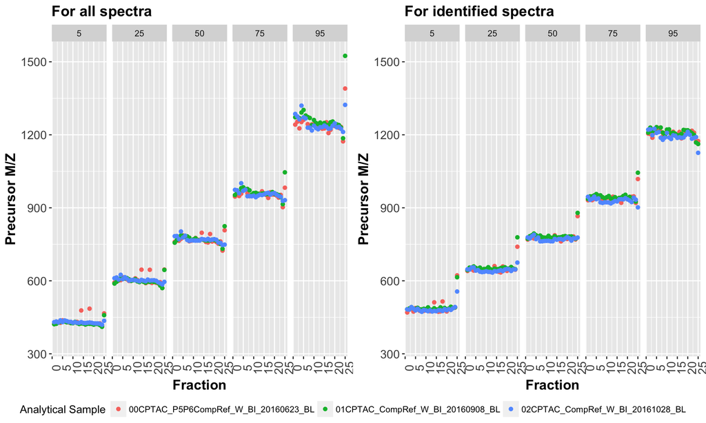

## Precursor molecular weight values

### Per sample, versus fraction (scatterplot)

This graph represents scatter plot of the 5%,25%,50%,75%,95% for precursor molecular weight values versus fractions in the same scale. Each panel is a different percentile. Each analytical sample is represented by a different color.

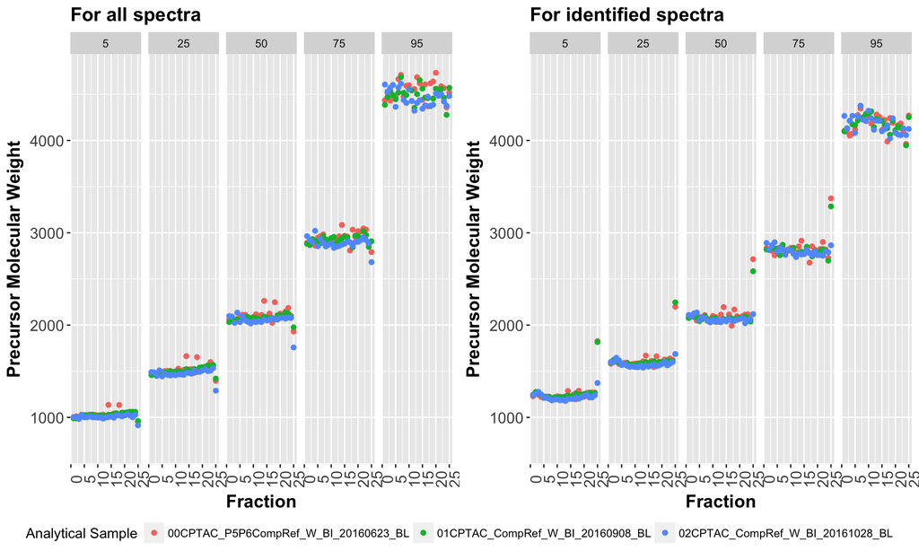

### Per sample, across fraction (boxplot)

This graph represents boxplot of the 5%,25%,50%,75%,95% for precursor molecular weight values across fractions in the same scale. Each panel is a different percentile. Each analytical sample is represented by a different color.

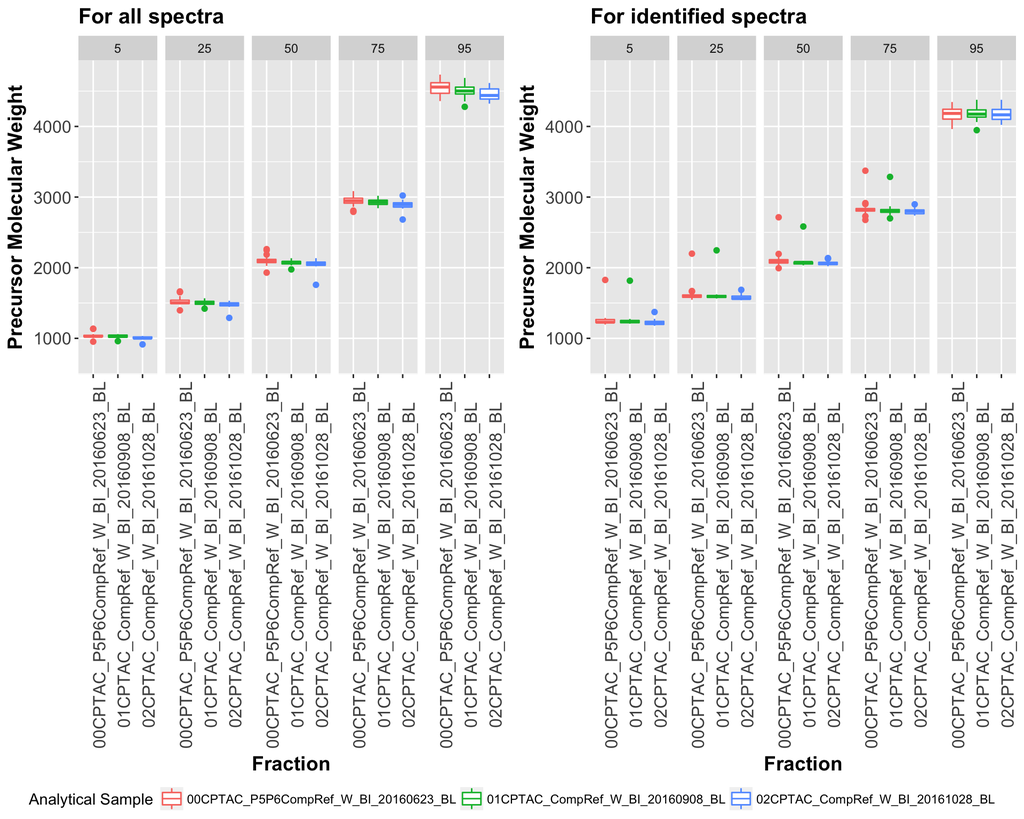

## MS2 per MS1 values

### Per sample, versus fraction (scatterplot)

This graph represents scatterplot of the 5%,25%,50%,75%,95% for MS2 per MS1 values versus fractions in the same scale. Each panel is a different percentile. Each analytical sample is represented by a different color.

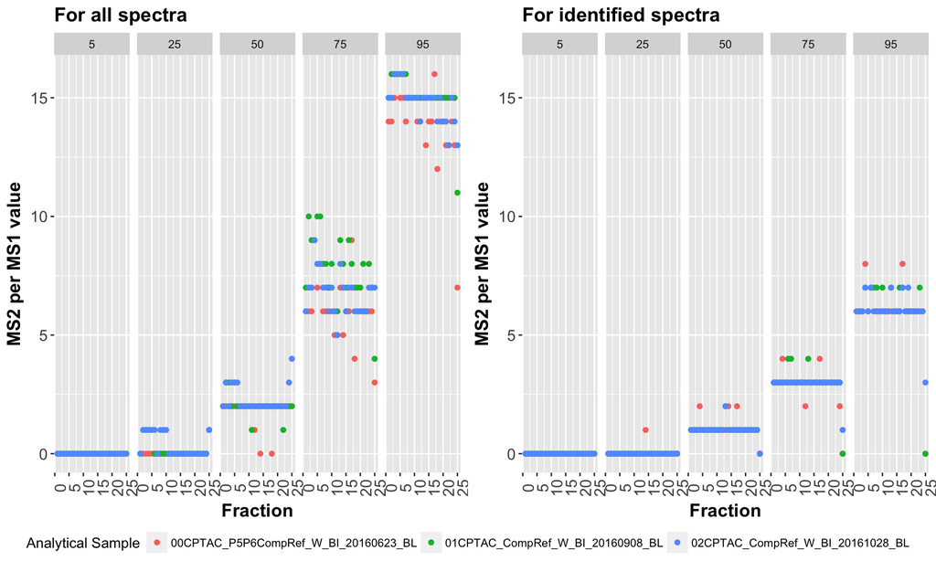

### Median of MS2 per MS1 value for all spectra

In this table, the meidian MS2 per MS1 value for each percentile is present, each column represents a different percentile.

The median of MS2 per MS1

|  | 5th Perc | 25th Perc | 50th Perc | 75th Perc | 95th Perc |
| --- | --- | --- | --- | --- | --- |
| 00CPTAC_P5P6CompRef_W_BI_20160623_BL | 0 | 0 | 2 | 6 | 14 |
| 01CPTAC_CompRef_W_BI_20160908_BL | 0 | 0 | 2 | 8 | 15 |
| 02CPTAC_CompRef_W_BI_20161028_BL | 0 | 0 | 2 | 7 | 15 |

### Median of MS2 per MS1 value for identified spectra

In this table, the meidian MS2 per MS1 value for each percentile is present, each column represents a different percentile.

The median of MS2 per MS1

|  | 5th Perc | 25th Perc | 50th Perc | 75th Perc | 95th Perc |
| --- | --- | --- | --- | --- | --- |
| 00CPTAC_P5P6CompRef_W_BI_20160623_BL | 0 | 0 | 1 | 3 | 6 |
| 01CPTAC_CompRef_W_BI_20160908_BL | 0 | 0 | 1 | 3 | 6 |
| 02CPTAC_CompRef_W_BI_20161028_BL | 0 | 0 | 1 | 3 | 6 |

### Table of values less than 20 for all spectra

In this table the percent for the values less than 20 are present, each column is a different percentile

Percent of samples’ value less than 20

|  | 5th Perc | 25th Perc | 50th Perc | 75th Perc | 95th Perc |
| --- | --- | --- | --- | --- | --- |
| 00CPTAC_P5P6CompRef_W_BI_20160623_BL | 100 | 100 | 100 | 100 | 100 |
| 01CPTAC_CompRef_W_BI_20160908_BL | 100 | 100 | 100 | 100 | 100 |
| 02CPTAC_CompRef_W_BI_20161028_BL | 100 | 100 | 100 | 100 | 100 |

### Table of values less than 20 for identified spectra

In this table the percent for the values less than 20 are present, each column is a different percentile

Percent of samples’ value less than 20

|  | 5th Perc | 25th Perc | 50th Perc | 75th Perc | 95th Perc |
| --- | --- | --- | --- | --- | --- |
| 00CPTAC_P5P6CompRef_W_BI_20160623_BL | 100 | 100 | 100 | 100 | 100 |
| 01CPTAC_CompRef_W_BI_20160908_BL | 100 | 100 | 100 | 100 | 100 |
| 02CPTAC_CompRef_W_BI_20161028_BL | 100 | 100 | 100 | 100 | 100 |

## Proportion of charge states for MS2 spectra

This graph represents proportion of charge states for MS2 spectra in the same scale. Each charge state of MS2 is represented by a different color.

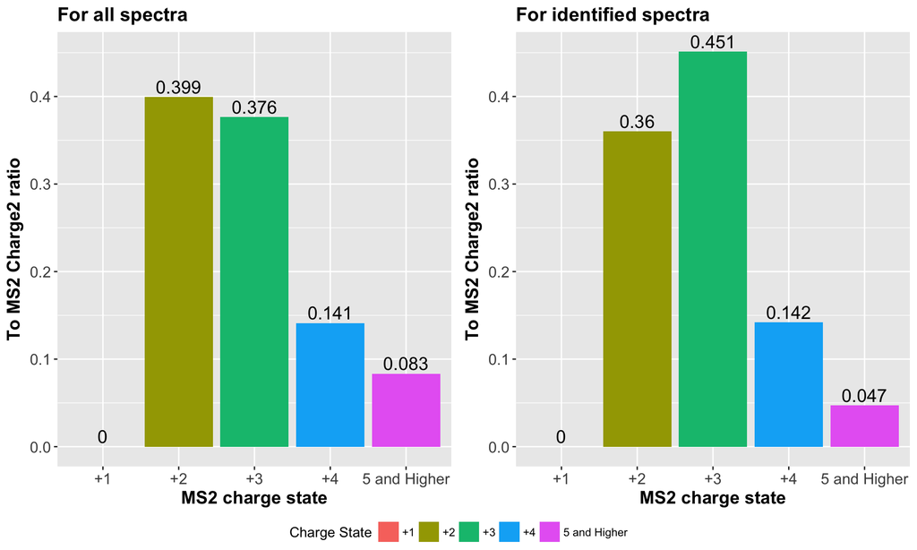